# MultivariateStatsTutorial

A substantial part of the code below is kindly adapted from Umer Ijaz’s excellent webpage [R code for ecological data analysis](http://userweb.eng.gla.ac.uk/umer.ijaz/bioinformatics/ecological.html):

## Contents

- Introduction
- Clustering
- Ordination
- Hypothesis testing
- Differential OTU abundance

## Introduction

The tutorial data can be downloaded from:

http://chrisquince.github.io/tutorials/MultivariateStatsTutorial.tar.gz

The tutorial assumes you have unarchived this file and are running R with pwd set to that directory.

We will begin by reading in the 5% OTU table and meta data for the AOA study discussed in the lectures. Note that we transpose OTU matrix:

```r
otus <- read.csv("AllSites_C05.csv",header=TRUE,row.names=1)
otus <- t(otus)
env <- read.csv("Env.csv",header=TRUE,row.names=1)
```

Load libraries:

```r
library(gplots)
library(ggplot2)
library(RColorBrewer)
library(vegan)
library(GUniFrac)
library(ggdendro)
library(picante)
library(grid)
library(reshape2)
library(DESeq2)
```

Filter samples with less than 1000 reads:

```r
otus_1e3 <- otus[rowSums(otus) > 1000,]
env_1e3 <- env[rownames(otus_1e3),]
```

Rarefy species richness:

```r
env_1e3$S_rare <-  rarefy(otus_1e3, 1000, se = FALSE, MARGIN = 1)
```

Note that we attach the dataframe to make variables visible and then test for correlation between rarefied diversity and pH:

```r
attach(env_1e3)
cor.test(S_rare,pH)
```

```
##
##  Pearson's product-moment correlation
##
## data:  S_rare and pH
## t = 2.7299, df = 42, p-value = 0.009217
## alternative hypothesis: true correlation is not equal to 0
## 95 percent confidence interval:
##  0.1032138 0.6142839
## sample estimates:
##       cor
## 0.3881989
```

Find a positive correlation which is confirmed by plot:

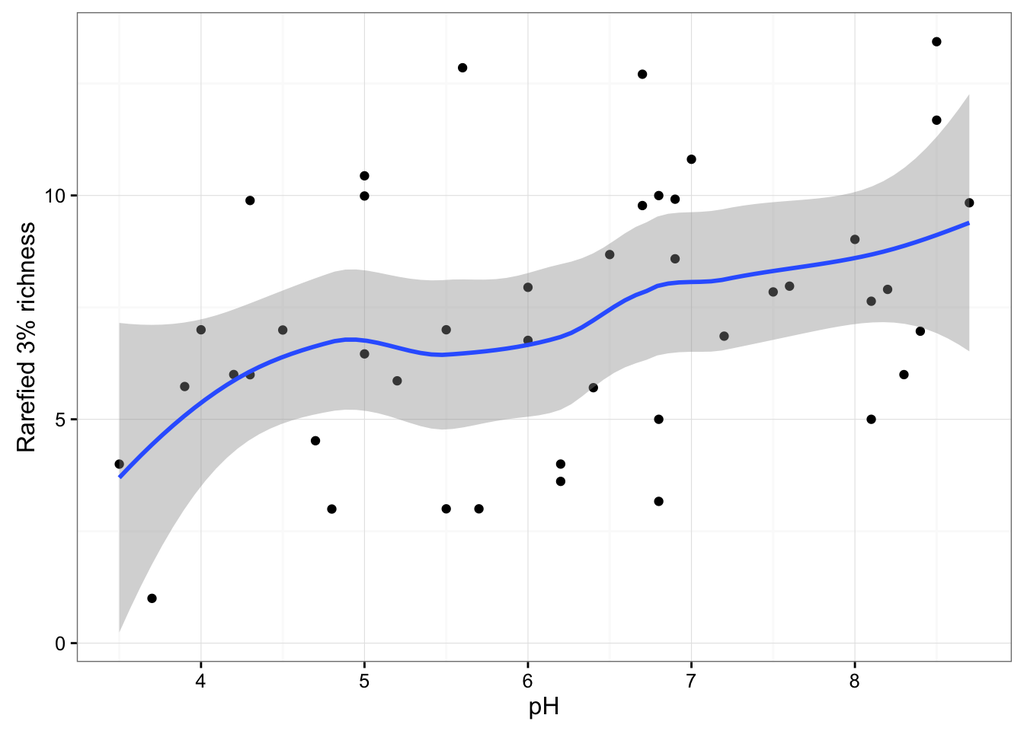

```r
p <- ggplot(data=env_1e3,aes(x=pH,y=S_rare)) + theme_bw() + geom_point() + geom_smooth() + ylab("Rarefied 3% richness") + xlab("pH")
plot(p)
```

## Clustering

Now we will generate a hierarchical clustering of samples:

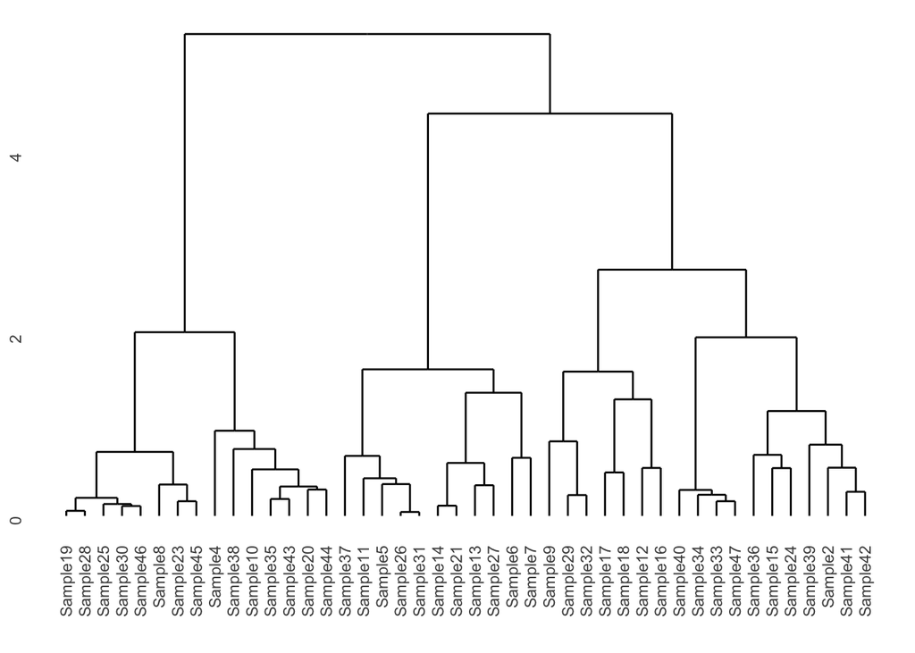

```r
otus_1e3P <- otus_1e3/rowSums(otus_1e3)

otus_1e3P.dist <- vegdist(otus_1e3P,dist="bray")

otus_1e3P.hclust <- hclust(otus_1e3P.dist,method="ward.D")

ggdendrogram(otus_1e3P.hclust, rotate = FALSE, size = 2)
```

A clustering is an exploratory form of data analysis, often a heatmap partcularly coupled to clustering is more useful. Here we only cluster the OTUs and order rows by pH to explore relationships between pH and abundance:

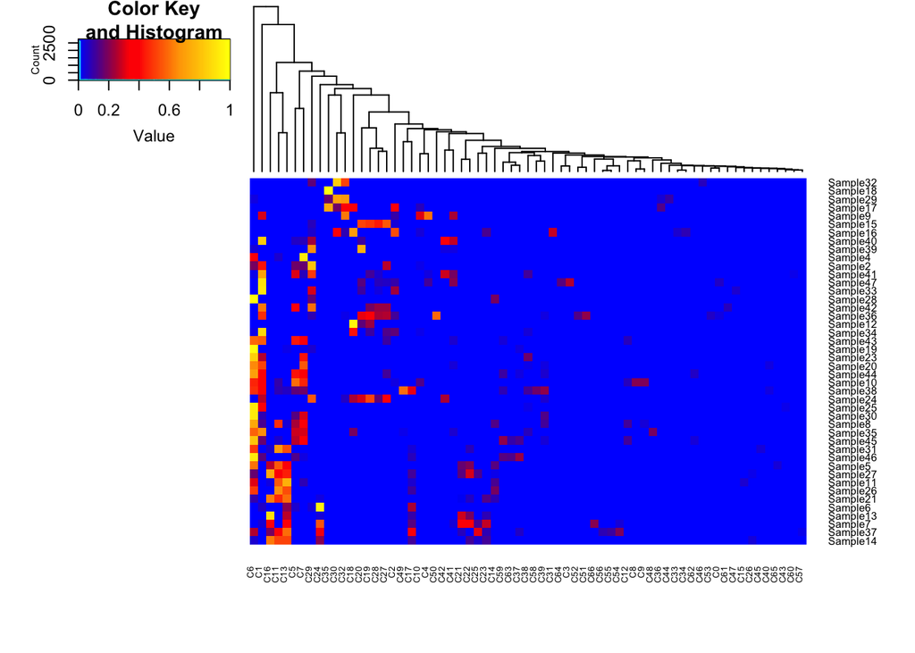

```r
crp <- colorRampPalette(c("blue","red","orange","yellow"))(100)
otusPH <- data.frame(otus_1e3P,pH=env_1e3$pH)
otusPH.order <- otusPH[order(env_1e3$pH),]
otusPH.order$pH <- NULL
otusPH.matrix <- as.matrix(otusPH.order)

heatmap.2 (sqrt(otusPH.matrix ),col=crp,trace="none",Rowv=FALSE,cexCol=0.5,cexRow=0.6)
```

## Ordination

### Principal components analysis

Now we will take a look at ordination starting with the most simple principal components analysis (PCA).

```r
otus_1e3P.pca <- rda(otus_1e3P)
```

First examinine eigenvalues:

```r
pca_eig <- eigenvals(otus_1e3P.pca)
summary(pca_eig)
```

```
## Importance of components:
##                          PC1     PC2     PC3     PC4     PC5     PC6
## Eigenvalue            0.1096 0.06583 0.03670 0.02706 0.02482 0.02321
## Proportion Explained  0.2827 0.16978 0.09466 0.06979 0.06402 0.05987
## Cumulative Proportion 0.2827 0.45243 0.54709 0.61688 0.68090 0.74077
##                           PC7     PC8     PC9     PC10     PC11    PC12
## Eigenvalue            0.02163 0.02091 0.01941 0.008989 0.006327 0.00483
## Proportion Explained  0.05578 0.05393 0.05005 0.023180 0.016320 0.01246
## Cumulative Proportion 0.79656 0.85049 0.90054 0.923730 0.940050 0.95250
##                           PC13     PC14     PC15     PC16     PC17
## Eigenvalue            0.003908 0.003498 0.002858 0.002465 0.001957
## Proportion Explained  0.010080 0.009020 0.007370 0.006360 0.005050
## Cumulative Proportion 0.962580 0.971610 0.978980 0.985330 0.990380
##                            PC18      PC19     PC20      PC21      PC22
## Eigenvalue            0.0009989 0.0007412 0.000613 0.0004924 0.0003652
## Proportion Explained  0.0025800 0.0019100 0.001580 0.0012700 0.0009400
## Cumulative Proportion 0.9929600 0.9948700 0.996450 0.9977200 0.9986600
##                            PC23      PC24      PC25      PC26      PC27
## Eigenvalue            0.0001082 9.121e-05 8.242e-05 4.334e-05 3.664e-05
## Proportion Explained  0.0002800 2.400e-04 2.100e-04 1.100e-04 9.000e-05
## Cumulative Proportion 0.9989400 9.992e-01 9.994e-01 9.995e-01 9.996e-01
##                            PC28      PC29      PC30      PC31      PC32
## Eigenvalue            0.0000336 2.749e-05 2.566e-05 2.161e-05 1.905e-05
## Proportion Explained  0.0000900 7.000e-05 7.000e-05 6.000e-05 5.000e-05
## Cumulative Proportion 0.9996800 9.998e-01 9.998e-01 9.999e-01 9.999e-01
##                            PC33      PC34      PC35      PC36      PC37
## Eigenvalue            1.714e-05 8.756e-06 2.354e-06 7.121e-07 4.107e-07
## Proportion Explained  4.000e-05 2.000e-05 1.000e-05 0.000e+00 0.000e+00
## Cumulative Proportion 1.000e+00 1.000e+00 1.000e+00 1.000e+00 1.000e+00
##                            PC38      PC39      PC40      PC41      PC42
## Eigenvalue            3.121e-07 2.331e-07 1.449e-07 4.382e-08 3.423e-08
## Proportion Explained  0.000e+00 0.000e+00 0.000e+00 0.000e+00 0.000e+00
## Cumulative Proportion 1.000e+00 1.000e+00 1.000e+00 1.000e+00 1.000e+00
##                            PC43
## Eigenvalue            1.016e-08
## Proportion Explained  0.000e+00
## Cumulative Proportion 1.000e+00
```

Can plot this with inbuilt vegan functions but result is quite ugly:

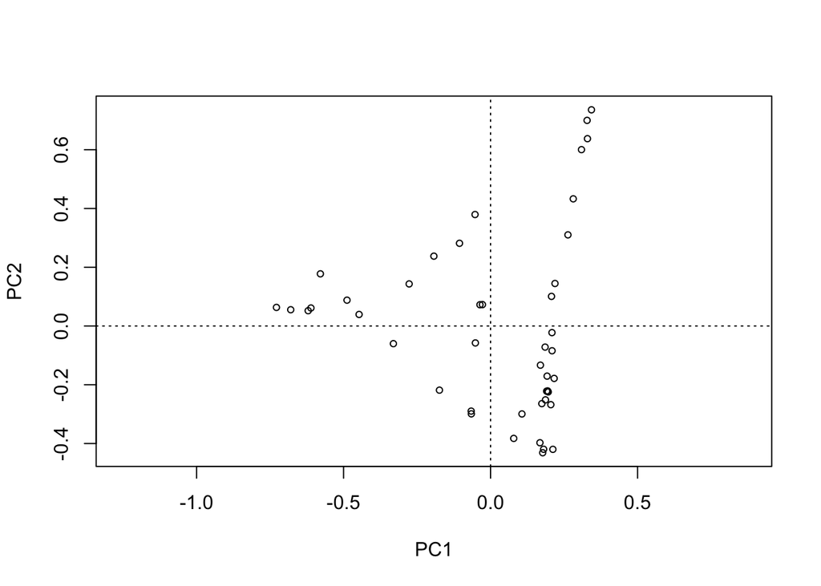

```r
ordiplot(otus_1e3P.pca,display="sites")
```

Instead we pull out PC1,PC2 of sites add pH and plot with ggplot2:

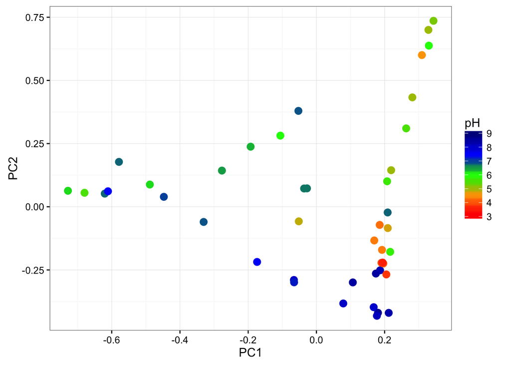

```r
pca_df<-scores(otus_1e3P.pca,display=c("sites"))

pca_df<-data.frame(cbind(pca_df,pH=env_1e3$pH))

crp2 <- colorRampPalette(c("red","orange","green","blue","darkblue"))

sc <- scale_colour_gradientn(colours = crp2(100), limits=c(3, 9))

p<-ggplot(data=pca_df,aes(PC1,PC2,colour=pH)) + geom_point(size=3) + sc + theme_bw()

plot(p)
```

# Correspondence analysis

Now lets try correspondence analysis:

```r
otus_1e3P.cca <- cca(otus_1e3P)

cca_df<-scores(otus_1e3P.cca,display=c("sites"))

cca_df<-data.frame(cbind(cca_df,pH=env_1e3$pH))

p<-ggplot(data=cca_df,aes(CA1,CA2,colour=pH)) + geom_point(size=3) + sc + theme_bw()
```

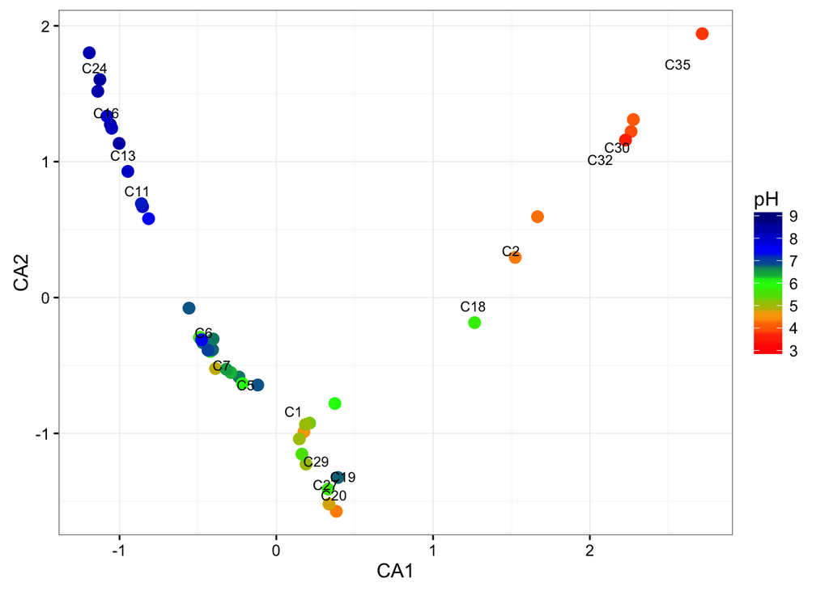

```r
species_df<-data.frame(scores(otus_1e3P.cca,display=c("species")))

species_df_01 <- species_df[colMeans(otus_1e3P) > 0.01,]

species_df_01$Name <- rownames(species_df_01)

species_plot_df <- data.frame(x=species_df_01$CA1,y=species_df_01$CA2,Name=rownames(species_df_01))

p <- p + geom_text(data=species_plot_df,aes(x,y,label=Name),size=3,inherit.aes=F)

plot(p)
```

### Principal coordinates analysis using generalised Unifrac

First we need to read in tree:

```r
tr <- read.tree("RAxML_bestTree.AllSite.tree")
```

Calculate Unifrac distances:

```r
otus_1e3P.gunifrac <- GUniFrac(otus_1e3P, tr, alpha=c(0, 0.5, 1))$unifracs
```

Extract weighted Unifrac distances:

```r
otus_1e3P.uf <- otus_1e3P.gunifrac[,,"d_1"]
```

Perform principle coordinates analysis and plot:

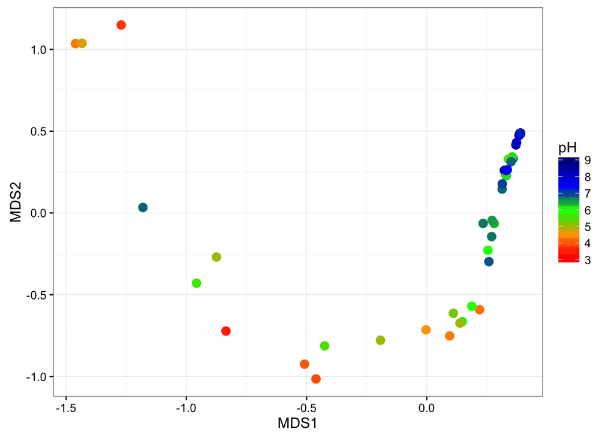

```r
otus_1e3P.cap <- capscale(otus_1e3P.uf ~ 1)

cap_uf_df<-scores(otus_1e3P.cap,display=c("sites"))

cap_uf_df<-data.frame(cbind(cap_uf_df,pH=env_1e3$pH))

p<-ggplot(data=cap_uf_df,aes(MDS1,MDS2,colour=pH)) + geom_point(size=3) + sc + theme_bw()

plot(p)
```

### NMDS

Probably the most useful method overall NMDS

```r
otus_1e3P.nmds <- metaMDS(otus_1e3P)
```

```
## *** Solution reached
```

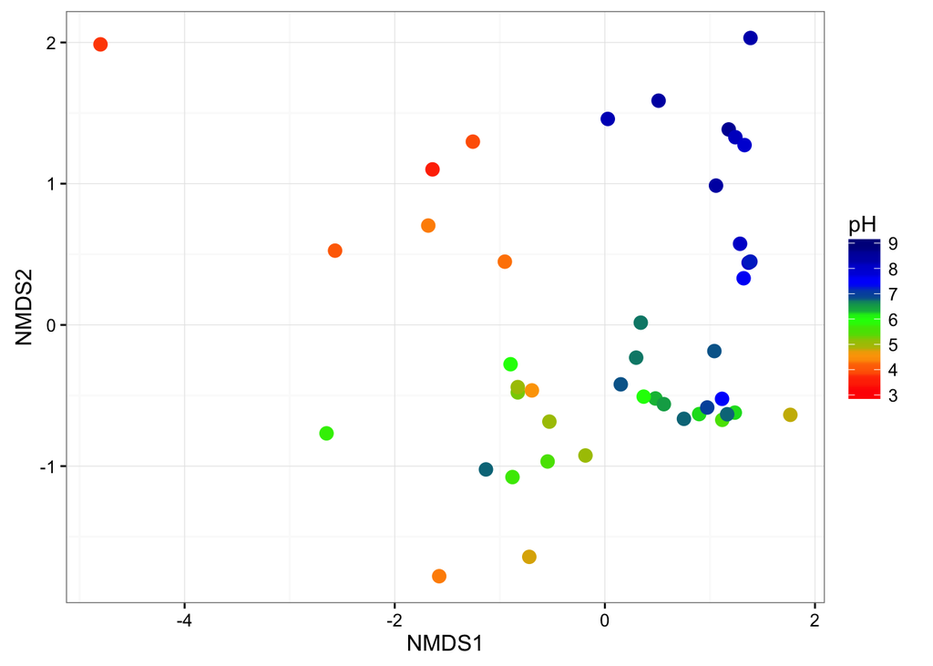

```r
nmds_df<-scores(otus_1e3P.nmds,display=c("sites"))

nmds_df<-data.frame(cbind(nmds_df,pH=env_1e3$pH))

p<-ggplot(data=nmds_df,aes(NMDS1,NMDS2,colour=pH)) + geom_point(size=3) + sc + theme_bw()

plot(p)
```

We will now demonstrate how to add environmental contours to plot.

```r
ordi<-ordisurf(otus_1e3P.nmds,env_1e3$pH,plot = FALSE, bs="ds")

ordi.grid <- ordi$grid #extracts the ordisurf object
str(ordi.grid) #it's a list though - cannot be plotted as is
```

```
## List of 3
##  $ x: num [1:31] -4.8 -4.58 -4.36 -4.14 -3.93 ...
##  $ y: num [1:31] -1.78 -1.65 -1.53 -1.4 -1.27 ...
##  $ z: num [1:31, 1:31] NA NA NA NA NA NA NA NA NA NA ...
```

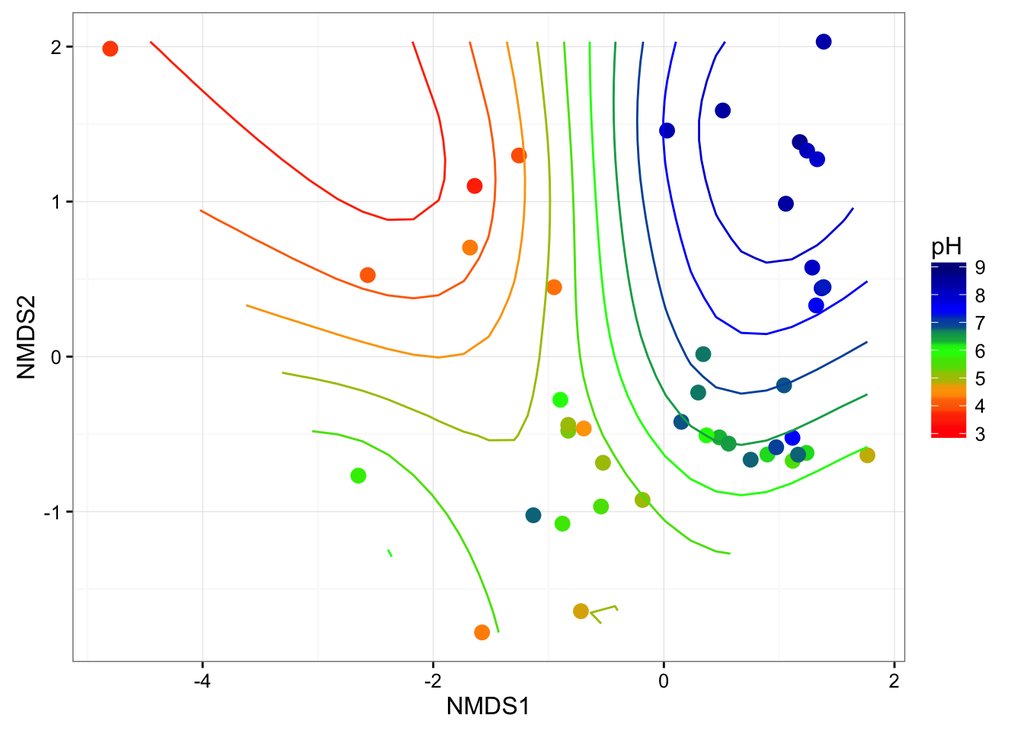

```r
ordi.mite <- expand.grid(x = ordi.grid$x, y = ordi.grid$y) #get x and ys
ordi.mite$z <- as.vector(ordi.grid$z) #unravel the matrix for the z scores
ordi.mite.na <- data.frame(na.omit(ordi.mite)) #gets rid of the nas

p<-p + stat_contour(data = ordi.mite.na, aes(x = x, y = y, z = z, colour =..level..))

plot(p)
```

Any distance can be used in NMDS e.g. comdist phylogenetically aware metric:

First need to generate cophenetic distance matrix from tree:

```r
tr.phydist <- cophenetic(tr)
```

Use this to calculate mean pairwise distance between all communities:

```r
otus_1e3P.comdist <- comdist(otus_1e3P, tr.phydist,abundance.weighted=TRUE)
#Perform NMDS using vegan metaMDS on those distances:
otus_1e3P.comdist.nmds <- metaMDS(otus_1e3P.comdist)
```

```
## *** No convergence -- monoMDS stopping criteria:
##     20: stress ratio > sratmax
```

and plot…

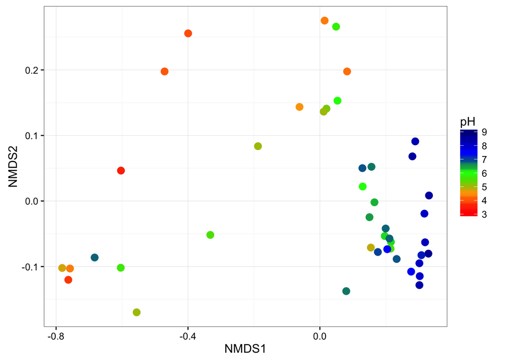

```r
nmds_comdist_df<-scores(otus_1e3P.comdist.nmds,display=c("sites"))

nmds_comdist_df<-data.frame(cbind(nmds_comdist_df,pH=env_1e3$pH))

p<-ggplot(data=nmds_comdist_df,aes(NMDS1,NMDS2,colour=pH)) + geom_point(size=3) + sc + theme_bw()

plot(p)
```

### Canonical correspondence analysis

We will now consider constrained ordinations beginning with CCA. Use same cca function but include regression formula:

```r
otus_1e3P.cca <- cca(otus_1e3P ~ pH + CN +  LOI + Moisture + vegetation,data=env_1e3)
```

What about significance – use random permutations of columns (OTUs) of community matrix?

```r
anova(otus_1e3P.cca)
```

```
## Permutation test for cca under reduced model
## Permutation: free
## Number of permutations: 999
##
## Model: cca(formula = otus_1e3P ~ pH + CN + LOI + Moisture + vegetation, data = env_1e3)
##          Df ChiSquare      F Pr(>F)
## Model     7    2.5334 2.0415  0.001 ***
## Residual 36    6.3823
## ---
## Signif. codes:  0 '***' 0.001 '**' 0.01 '*' 0.05 '.' 0.1 ' ' 1
```

```r
anova(otus_1e3P.cca, by="terms")
```

```
## Permutation test for cca under reduced model
## Terms added sequentially (first to last)
## Permutation: free
## Number of permutations: 999
##
## Model: cca(formula = otus_1e3P ~ pH + CN + LOI + Moisture + vegetation, data = env_1e3)
##            Df ChiSquare      F Pr(>F)
## pH          1    0.8150 4.5973  0.001 ***
## CN          1    0.1810 1.0210  0.452
## LOI         1    0.4784 2.6983  0.004 **
## Moisture    1    0.2640 1.4893  0.079 .
## vegetation  3    0.7950 1.4948  0.004 **
## Residual   36    6.3823
## ---
## Signif. codes:  0 '***' 0.001 '**' 0.01 '*' 0.05 '.' 0.1 ' ' 1
```

```r
otus_1e3PR.cca <- cca(otus_1e3P ~ pH + LOI + vegetation,data=env_1e3)

scrs<-scores(otus_1e3PR.cca,display=c("sp","wa","lc","bp","cn"))

nmds_df<-scores(otus_1e3PR.cca,display=c("sites"))

#Check the attributes

attributes(scrs)
```

```
## $names
## [1] "species"     "sites"       "constraints" "biplot"      "centroids"
```

```r
#Extract site data first

df_sites <- data.frame(cbind(scrs$sites,pH=env_1e3$pH))

p<-ggplot(data=df_sites,aes(CCA1,CCA2,colour=pH)) + geom_point(size=3) + sc + theme_bw()
```

No we biplot on the environmental variables:

```r
multiplier <- vegan:::ordiArrowMul(scrs$biplot)
```

Reference: http://www.inside-r.org/packages/cran/vegan/docs/envfit

The printed output of continuous variables (vectors) gives the direction cosines which are the coordinates of the heads of unit length vectors. In plot these are scaled by their correlation (square root of the column r2) so that “weak” predictors have shorter arrows than “strong” predictors. You can see the scaled relative lengths using command scores. The plotted (and scaled) arrows are further adjusted to the current graph using a constant multiplier: this will keep the relative r2-scaled lengths of the arrows but tries to fill the current plot. You can see the multiplier using vegan:::ordiArrowMul(result_of_envfit), and set it with the argument arrow.mul.

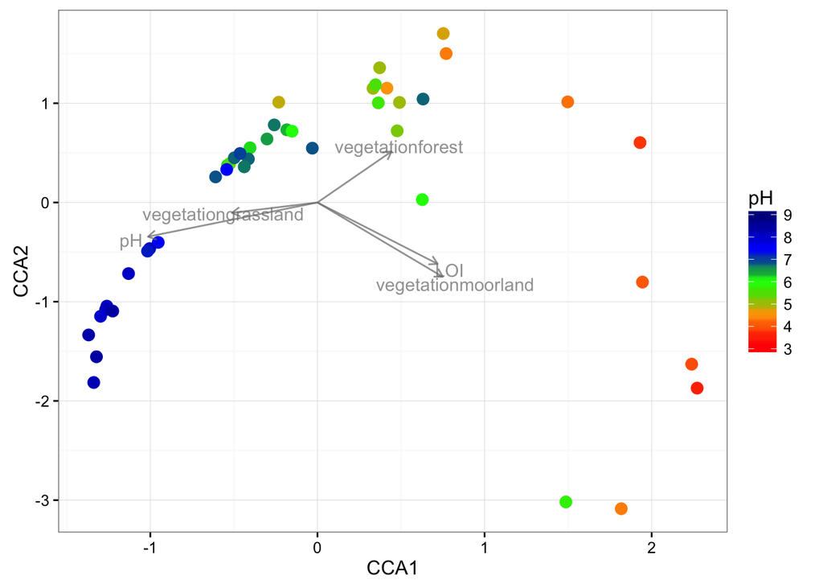

```r
df_arrows<- scrs$biplot*multiplier
colnames(df_arrows)<-c("x","y")
df_arrows=as.data.frame(df_arrows)

p<-p+geom_segment(data=df_arrows, aes(x = 0, y = 0, xend = x, yend = y),
                 arrow = arrow(length = unit(0.2, "cm")),color="#808080",alpha=0.75)

p<-p+geom_text(data=as.data.frame(df_arrows*1.1),aes(x, y, label = rownames(df_arrows)),color="#808080",alpha=0.75)

plot(p)
```

### Constrained Analysis of Principal Coordinates using Unifrac

Use same capscale function but include regression formula:

```r
otus_1e3P.uf.cap <- capscale(otus_1e3P.uf  ~ pH + CN +  LOI + Moisture+ vegetation,data=env_1e3)
```

What about significance – use random permutations of columns (OTUs) of community matrix?

```r
anova(otus_1e3P.uf.cap)
```

```
## Permutation test for capscale under reduced model
## Permutation: free
## Number of permutations: 999
##
## Model: capscale(formula = otus_1e3P.uf ~ pH + CN + LOI + Moisture + vegetation, data = env_1e3)
##          Df SumOfSqs      F Pr(>F)
## Model     7   2.0034 4.7594  0.001 ***
## Residual 36   2.1648
## ---
## Signif. codes:  0 '***' 0.001 '**' 0.01 '*' 0.05 '.' 0.1 ' ' 1
```

```r
anova(otus_1e3P.uf.cap, perm.max=2000,perm=2000,by="terms")
```

```
## Permutation test for capscale under reduced model
## Terms added sequentially (first to last)
## Permutation: free
## Number of permutations: 999
##
## Model: capscale(formula = otus_1e3P.uf ~ pH + CN + LOI + Moisture + vegetation, data = env_1e3)
##            Df SumOfSqs       F Pr(>F)
## pH          1  1.25611 20.8891  0.001 ***
## CN          1  0.04714  0.7839  0.451
## LOI         1  0.09922  1.6500  0.179
## Moisture    1  0.07521  1.2508  0.252
## vegetation  3  0.52568  2.9140  0.014 *
## Residual   36  2.16476
## ---
## Signif. codes:  0 '***' 0.001 '**' 0.01 '*' 0.05 '.' 0.1 ' ' 1
```

Now only pH and vegatation significant.

```r
otus_1e3P.uf.cap <- capscale(otus_1e3P.uf  ~ pH + vegetation,data=env_1e3)

scrs<-scores(otus_1e3P.uf.cap,display=c("sp","wa","lc","bp","cn"))

nmds_df<-scores(otus_1e3PR.cca,display=c("sites"))

#Check the attributes

attributes(scrs)
```

```
## $names
## [1] "species"     "sites"       "constraints" "biplot"      "centroids"
##
## $const
## [1] 3.658913
```

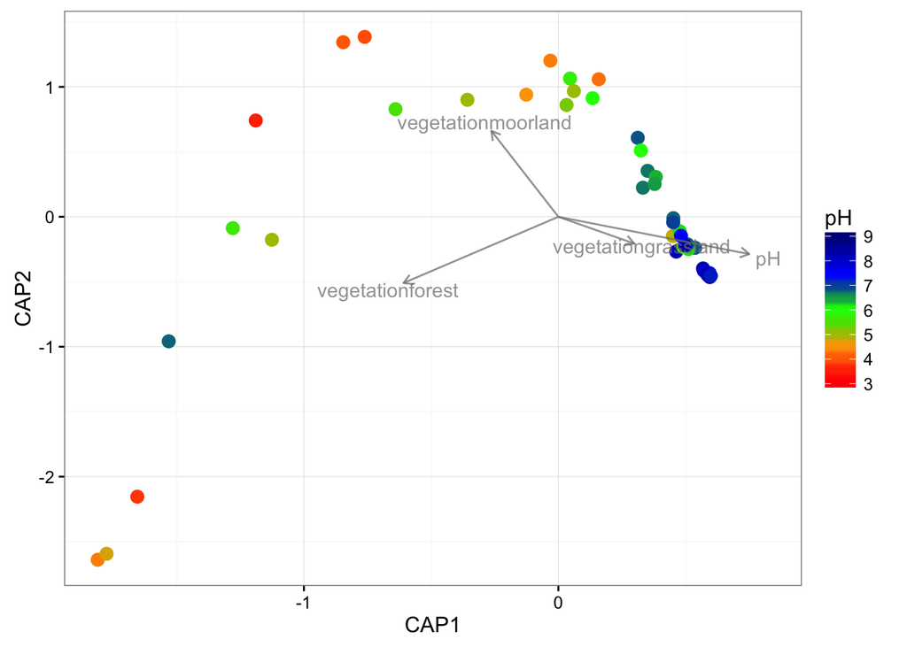

```r
#Extract site data first

df_sites <- data.frame(cbind(scrs$sites,pH=env_1e3$pH))

p<-ggplot(data=df_sites,aes(CAP1,CAP2,colour=pH)) + geom_point(size=3) + sc + theme_bw()

multiplier <- vegan:::ordiArrowMul(scrs$biplot)

df_arrows<- scrs$biplot*multiplier
colnames(df_arrows)<-c("x","y")
df_arrows=as.data.frame(df_arrows)

p<-p+geom_segment(data=df_arrows, aes(x = 0, y = 0, xend = x, yend = y),
                 arrow = arrow(length = unit(0.2, "cm")),color="#808080",alpha=0.75)

p<-p+geom_text(data=as.data.frame(df_arrows*1.1),aes(x, y, label = rownames(df_arrows)),color="#808080",alpha=0.75)

plot(p)
```

## Hypothesis testing

Permutational Multivariate Analysis can be applied to any distance measure independent of ordination e.g. Bray-Curtis:

```r
otus_1e3.ado <- adonis(otus_1e3P ~ ., data= env_1e3)

otus_1e3.ado
```

```
##
## Call:
## adonis(formula = otus_1e3P ~ ., data = env_1e3)
##
## Permutation: free
## Number of permutations: 999
##
## Terms added sequentially (first to last)
##
##            Df SumsOfSqs MeanSqs F.Model      R2 Pr(>F)
## pH          1    2.3115 2.31150  8.3512 0.13778  0.001 ***
## C           1    1.1315 1.13153  4.0881 0.06744  0.001 ***
## N           1    0.5480 0.54800  1.9799 0.03266  0.051 .
## CN          1    0.5600 0.56002  2.0233 0.03338  0.030 *
## Moisture    1    0.2461 0.24611  0.8892 0.01467  0.504
## LOI         1    0.4680 0.46804  1.6910 0.02790  0.097 .
## vegetation  3    1.5144 0.50481  1.8238 0.09027  0.011 *
## S_rare      1    0.8635 0.86355  3.1199 0.05147  0.002 **
## Residuals  33    9.1339 0.27679         0.54443
## Total      43   16.7771                 1.00000
## ---
## Signif. codes:  0 '***' 0.001 '**' 0.01 '*' 0.05 '.' 0.1 ' ' 1
```

```r
#Compare to phylogenetically aware metric:
otus_1e3.comdist.ado <- adonis(otus_1e3P.comdist ~ ., data=env_1e3)

otus_1e3.comdist.ado
```

```
##
## Call:
## adonis(formula = otus_1e3P.comdist ~ ., data = env_1e3)
##
## Permutation: free
## Number of permutations: 999
##
## Terms added sequentially (first to last)
##
##            Df SumsOfSqs MeanSqs F.Model      R2 Pr(>F)
## pH          1    2.8069 2.80690 21.6338 0.32197  0.001 ***
## C           1    0.1934 0.19339  1.4905 0.02218  0.164
## N           1    0.1216 0.12159  0.9371 0.01395  0.398
## CN          1    0.1566 0.15661  1.2070 0.01796  0.278
## Moisture    1    0.1360 0.13600  1.0482 0.01560  0.343
## LOI         1    0.2000 0.20003  1.5417 0.02295  0.201
## vegetation  3    0.5767 0.19223  1.4816 0.06615  0.169
## S_rare      1    0.2450 0.24498  1.8882 0.02810  0.137
## Residuals  33    4.2816 0.12975         0.49114
## Total      43    8.7178                 1.00000
## ---
## Signif. codes:  0 '***' 0.001 '**' 0.01 '*' 0.05 '.' 0.1 ' ' 1
```

```r
#And Unifrac:
otus_1e3.uf.ado <- adonis(otus_1e3P.uf  ~ ., data=env_1e3)

otus_1e3.uf.ado
```

```
##
## Call:
## adonis(formula = otus_1e3P.uf ~ ., data = env_1e3)
##
## Permutation: free
## Number of permutations: 999
##
## Terms added sequentially (first to last)
##
##            Df SumsOfSqs MeanSqs F.Model      R2 Pr(>F)
## pH          1    1.2561 1.25611 21.6465 0.30136  0.001 ***
## C           1    0.1159 0.11588  1.9969 0.02780  0.121
## N           1    0.0294 0.02941  0.5069 0.00706  0.583
## CN          1    0.0379 0.03794  0.6538 0.00910  0.526
## Moisture    1    0.0676 0.06756  1.1643 0.01621  0.268
## LOI         1    0.0883 0.08834  1.5223 0.02119  0.184
## vegetation  3    0.4994 0.16647  2.8687 0.11981  0.022 *
## S_rare      1    0.1585 0.15854  2.7322 0.03804  0.064 .
## Residuals  33    1.9149 0.05803         0.45942
## Total      43    4.1681                 1.00000
## ---
## Signif. codes:  0 '***' 0.001 '**' 0.01 '*' 0.05 '.' 0.1 ' ' 1
```

Mantel tests are another ordination free method of linking environment and community structure:

```r
envN <- env_1e3[,1:6]

envN.dist <- vegdist(scale(envN), "euclid")

otus_1e3P.dist <- vegdist(otus_1e3P,method="bray")

mantel(otus_1e3P.dist,envN.dist)
```

```
##
## Mantel statistic based on Pearson's product-moment correlation
##
## Call:
## mantel(xdis = otus_1e3P.dist, ydis = envN.dist)
##
## Mantel statistic r: 0.3992
##       Significance: 0.001
##
## Upper quantiles of permutations (null model):
##    90%    95%  97.5%    99%
## 0.0919 0.1185 0.1362 0.1598
## Permutation: free
## Number of permutations: 999
```

```r
mantel(otus_1e3P.uf,envN.dist)
```

```
##
## Mantel statistic based on Pearson's product-moment correlation
##
## Call:
## mantel(xdis = otus_1e3P.uf, ydis = envN.dist)
##
## Mantel statistic r: 0.2422
##       Significance: 0.031
##
## Upper quantiles of permutations (null model):
##   90%   95% 97.5%   99%
## 0.156 0.211 0.249 0.318
## Permutation: free
## Number of permutations: 999
```

## Differential OTU abundance across samples

We are now going to read in the Crohn’s disease study data from our earlier tutorial:

```r
otus <- read.csv("otus.csv",header=TRUE,row.names=1)
meta <- read.csv("meta.csv",header=TRUE,row.names=1)
```

We begin by subsetting the data and meta data files to just the control samples and those from the beginning of EEN treatment:

```r
meta_CDH <- subset(meta,meta$Sample == "A")
otus_CDH <- subset(otus,meta$Sample == "A")
```

and filtering out samples with less than 10,000 reads.

```r
otus_CDH_1e4 <- otus_CDH[rowSums(otus_CDH)>1e4,]
meta_CDH_1e4 <- meta_CDH[rownames(otus_CDH_1e4),]
```

Now we add pseud-count, calculate proportions and log-transform:

```r
otus_CDH_1e4 <- otus_CDH_1e4[,colSums(otus_CDH_1e4) > 0]
otus_CDHP <- otus_CDH_1e4/rowSums(otus_CDH_1e4)
otus_CDH1 <- otus_CDH_1e4 + 1
otus_CDH_logP <- log(otus_CDH1/rowSums(otus_CDH1))
```

We will show all the code here but normally you might put this in a little function:

```r
nT <- ncol(otus_CDH_logP)
p <- rep(0,nT)
chi <- rep(0,nT)

meanH <- rep(0,nT)
meanCD <- rep(0,nT)

for(i in 1:nT){
    temp <- kruskal.test(otus_CDH_logP[,i] ~ meta_CDH_1e4$Type)
  tmean <- aggregate(otus_CDHP[,i]~meta_CDH_1e4$Type, FUN=mean)
    chi[i] <- temp$statistic
    p[i] <- temp$p.value
    meanCD[i] <- tmean[[2]][1]
    meanH[i] <- tmean[[2]][2]
}
```

Now we use Benjamini-Hochberg correction and group results back into data frame:

```r
pa <- p.adjust(p, method = "BH")
sig.df <- data.frame(chi,p,pa,meanH,meanCD)
rownames(sig.df) <- colnames(otus_CDH_logP)
```

Look at top ten most significant OTUs

```r
sig10 <- head(sig.df[order(sig.df$p),],10)

sig10
```

```
##              chi            p           pa        meanH       meanCD
## OTU_10  25.29553 4.918482e-07 0.0003165023 2.624707e-02 1.585491e-03
## OTU_69  25.01368 5.692487e-07 0.0003165023 8.021333e-05 6.611712e-03
## OTU_337 21.75474 3.098240e-06 0.0009870241 3.350748e-03 6.446906e-05
## OTU_88  21.49342 3.550447e-06 0.0009870241 1.847523e-03 1.219845e-04
## OTU_657 20.46395 6.076512e-06 0.0010999586 5.371392e-04 2.508751e-05
## OTU_164 20.21053 6.937017e-06 0.0010999586 3.419507e-04 1.440060e-05
## OTU_192 19.95868 7.913372e-06 0.0010999586 1.177226e-03 4.503702e-05
## OTU_60  19.95868 7.913372e-06 0.0010999586 4.727844e-03 1.563997e-04
## OTU_20  19.21263 1.169371e-05 0.0014448223 3.038438e-02 4.809983e-03
## OTU_46  15.91895 6.611354e-05 0.0069690024 1.070494e-02 1.687980e-04
```

Plot these as boxplots:

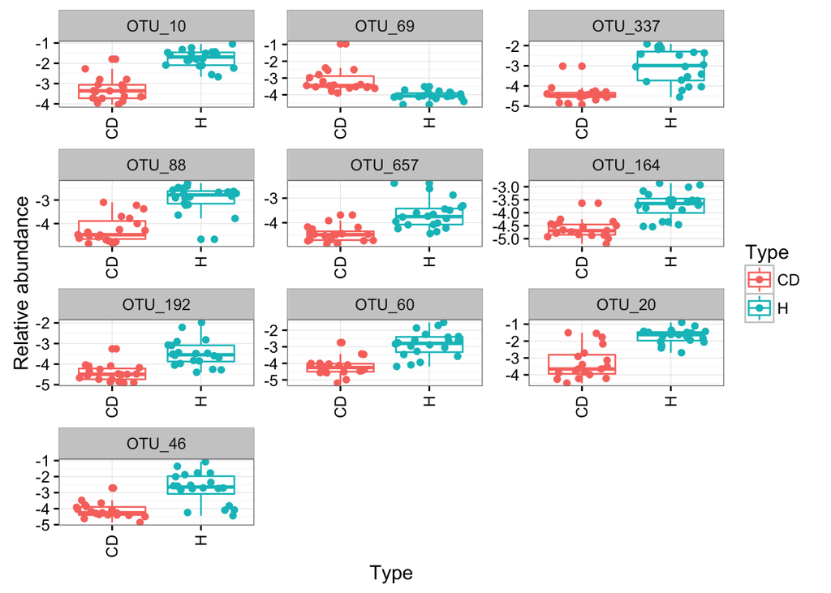

```r
otus_CDHP_sig10 <- (t(otus_CDH_logP)[rownames(sig10),])/log(10)

melt_sig10 <- melt(otus_CDHP_sig10)
colnames(melt_sig10) <- c("Taxa","Sample","Abundance")

type_sig10 <- factor(rep("CD",nrow(melt_sig10)),levels=c("CD","H"))

i=1
for (samplei in melt_sig10$Sample){
  type_sig10[i] <- meta_CDH_1e4[samplei,]$Type
  i=i+1
}

melt_sig10$Type <- type_sig10

p<-ggplot(melt_sig10,aes(Type,Abundance,colour=Type))+ylab("Relative abundance")
p<-p+geom_boxplot()+geom_jitter()+theme_bw()+
  facet_wrap( ~ Taxa , scales="free", ncol=3)
p<-p+theme(axis.text.x=element_text(angle=90,hjust=1,vjust=0.5))

plot(p)
```

```r
#We will convert our table to DESeqDataSet object
otus_CDH0 <- otus_CDH_1e4[,colSums(otus_CDH_1e4) > 0]

countData = round(as(otus_CDH0, "matrix"), digits = 0)

countData<-t(countData)

dds <- DESeqDataSetFromMatrix(countData, meta_CDH_1e4, as.formula(~ Type))
dds <- estimateSizeFactors(dds)
dds <- estimateDispersions(dds)
```

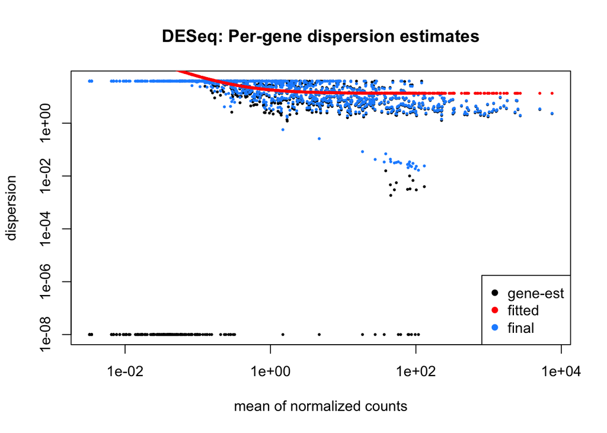

```r
plotDispEsts(dds, main="DESeq: Per-gene dispersion estimates")
```

```r
data_deseq_test = DESeq(dds)
```

```
## found already estimated dispersions, replacing these
```

```
## -- replacing outliers and refitting for 541 genes
## -- DESeq argument 'minReplicatesForReplace' = 7
## -- original counts are preserved in counts(dds)
```

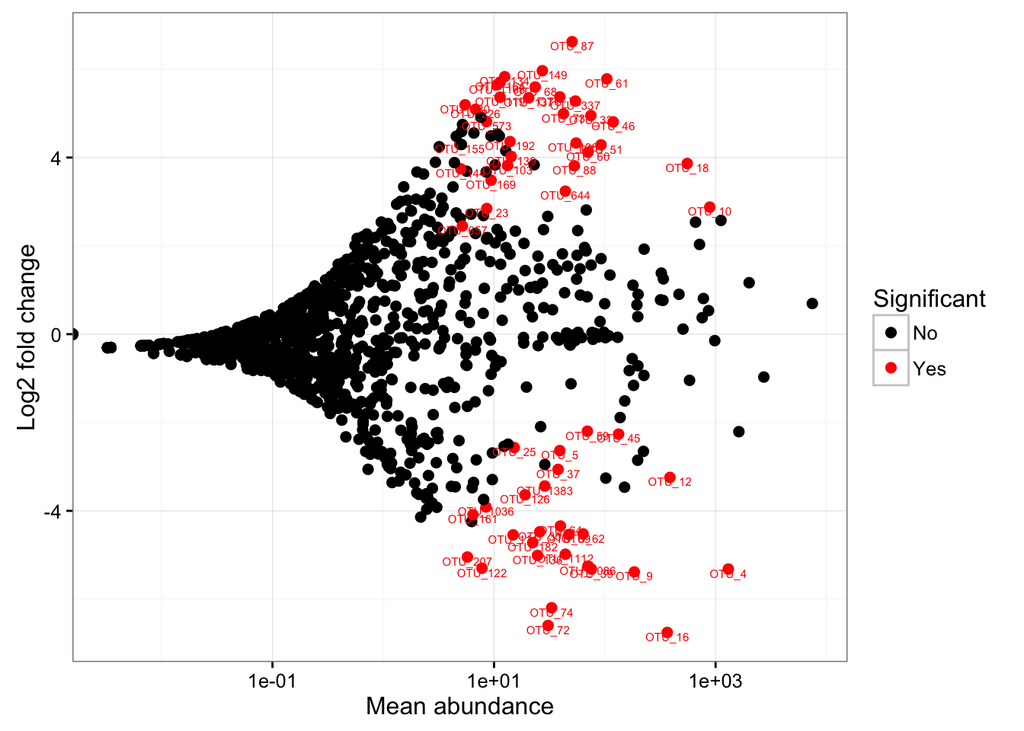

```r
## Extract the results
res = results(data_deseq_test, cooksCutoff = FALSE)
res_tax = cbind(as.data.frame(res), as.matrix(countData[rownames(res), ]), OTU = rownames(res))

sig = 0.001
fold = 0
plot.point.size = 2
label=T
tax.display = NULL
tax.aggregate = "OTU"

res_tax_sig = subset(res_tax, padj < sig & fold < abs(log2FoldChange))

res_tax_sig <- res_tax_sig[order(res_tax_sig$padj),]

## Plot the data
### MA plot
res_tax$Significant <- ifelse(rownames(res_tax) %in% rownames(res_tax_sig) , "Yes", "No")
res_tax$Significant[is.na(res_tax$Significant)] <- "No"
p1 <- ggplot(data = res_tax, aes(x = baseMean, y = log2FoldChange, color = Significant)) +
  geom_point(size = plot.point.size) +
  scale_x_log10() +
  scale_color_manual(values=c("black", "red")) +
  labs(x = "Mean abundance", y = "Log2 fold change")+theme_bw()

rlab <- data.frame(res_tax,Display=res_tax[,"OTU"])

p1 <- p1 + geom_text(data = subset(rlab, Significant == "Yes"), aes(label = Display), size = 2, vjust = 1)

plot(p1)
```

Also plot top ten most significant DESeq OTUs…

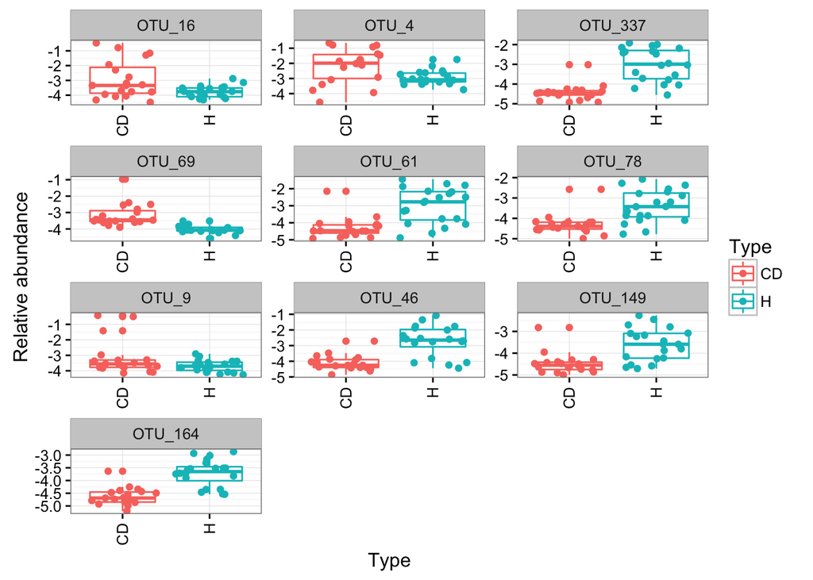

```r
head_deseq10 <- head(res[order(res$padj),],10)

otus_CDHP_sig10 <- (t(otus_CDH_logP)[rownames(head_deseq10),])/log(10)

melt_sig10 <- melt(otus_CDHP_sig10)
colnames(melt_sig10) <- c("Taxa","Sample","Abundance")

type_sig10 <- factor(rep("CD",nrow(melt_sig10)),levels=c("CD","H"))

i=1
for (samplei in melt_sig10$Sample){
  type_sig10[i] <- meta_CDH_1e4[samplei,]$Type
  i=i+1
}

melt_sig10$Type <- type_sig10

p<-ggplot(melt_sig10,aes(Type,Abundance,colour=Type))+ylab("Relative abundance")
p<-p+geom_boxplot()+geom_jitter()+theme_bw()+
  facet_wrap( ~ Taxa , scales="free", ncol=3)
p<-p+theme(axis.text.x=element_text(angle=90,hjust=1,vjust=0.5))

plot(p)
```